# Unit 3.4: The Acceptance-Rejection Method

Dr. Manoj C. Patil

2026-08-19

# 1 Learning Objectives

By the end of this unit, a student should be able to

- explain why the inverse transformation method of Unit 3.3 is insufficient whenever a quantile function is unavailable, and how the acceptance-rejection method fills this gap,
- state and prove that the acceptance-rejection algorithm produces a variate with exactly the target density, using the conditional distribution of the accepted candidate,
- derive the bounding constant $M$ that governs the algorithm and explain why the tightest valid $M$ minimizes computational cost,
- define exponential tilting and use it to construct an efficient envelope for simulating extreme-tail events,
- implement the acceptance-rejection algorithm in R for both a bounded and an unbounded target density, and empirically verify the theoretical acceptance probability,
- evaluate when the method is advantageous relative to alternative generation techniques, and diagnose common implementation errors.

# 2 Prerequisites

A reader should already be comfortable with

- the inverse transformation method and the notion of a quantile function (Unit 3.3),
- basic probability density manipulations, including conditioning on an event and computing conditional densities,
- elementary calculus, in particular locating the maximum of a smooth function by differentiation,
- the moment generating function of a random variable,
- generating Uniform$(0,1)$ and Exponential random variables in R.

# 3 Introduction

The inverse transformation method reduces the problem of simulating any random variable to a single recipe: draw a uniform variate and apply the quantile function. The recipe is elegant, but it has a practical weak point. Many distributions that arise routinely in statistics — the Gamma distribution for non-integer shape parameter, the standard Normal distribution, most posterior distributions encountered in Bayesian inference — do not admit a quantile function in closed form, and numerical inversion of the cumulative distribution function at every draw can be slow or numerically delicate. The acceptance-rejection method, sometimes called rejection sampling, addresses exactly this situation. It requires no quantile function at all; it requires only the ability to evaluate the target density (possibly up to an unknown multiplicative constant) and the ability to simulate from some other, more convenient distribution.

The idea originates with John von Neumann, who described it in an unpublished 1947 note in connection with Monte Carlo calculations for the Manhattan Project, and it was popularized in the open literature through the 1950s and 1960s as electronic computing made large-scale simulation practical. The method’s genius lies in converting a sampling problem into a geometric one: if a target density can be enclosed beneath a scaled version of a density that is easy to sample, then sampling uniformly from the region beneath the easy density and discarding points that fall above the target curve leaves behind points that are exactly distributed according to the target. No inversion, and no closed-form cumulative distribution function, is required anywhere in the procedure.

The practical importance of the method extends well beyond distributions lacking a quantile function. In Bayesian statistics, a posterior density is typically known only up to an unknown normalizing constant — the method, remarkably, still works without ever needing that constant, which makes it a natural exact-sampling benchmark against which approximate Markov chain Monte Carlo methods are compared. In reliability and insurance mathematics, a refinement of the method known as exponential tilting makes it possible to simulate efficiently from the extreme tail of a distribution, a setting in which naive methods waste nearly all of their computational effort. This unit develops the theory, the choice of the bounding constant $M$, exponential tilting, and the algorithms in full.

# 4 Intuition

Picture the graph of a target probability density $f$, and suppose it is possible to draw, at will, a random point that lands uniformly somewhere on or under the graph of some *other* curve $Mg(x)$, where $g$ is itself a probability density that is easy to sample from and $M \ge 1$ is a constant large enough that $Mg(x)$ lies everywhere on or above $f(x)$. If a large number of such uniformly scattered points are generated under the curve $Mg$, then the subset of those points that happen to fall *under* the curve $f$ is, geometrically, uniformly scattered under $f$ — and a point uniformly scattered under a density curve has, as its horizontal coordinate, exactly a draw from that density. Points falling above $f$ but still under $Mg$ are simply discarded (“rejected”); the surviving (“accepted”) points supply an exact sample from $f$.

Turning this geometric picture into an algorithm requires only a way to generate a point uniformly under $Mg$. This is done in two stages: first draw the horizontal coordinate $Y$ from the density $g$ (which is assumed to be easy), and then, conditional on $Y=y$, draw the vertical coordinate uniformly between $0$ and $Mg(y)$. The point is accepted if this vertical coordinate falls at or below $f(y)$. Because comparing a Uniform$(0,1)$ draw $U$ against the ratio $f(y)/(Mg(y))$ is equivalent to comparing a uniform draw on $(0, Mg(y))$ against $f(y)$, the acceptance rule reduces to the single check $U \le f(y)/(Mg(y))$, with no reference to areas or integrals needed at run time.

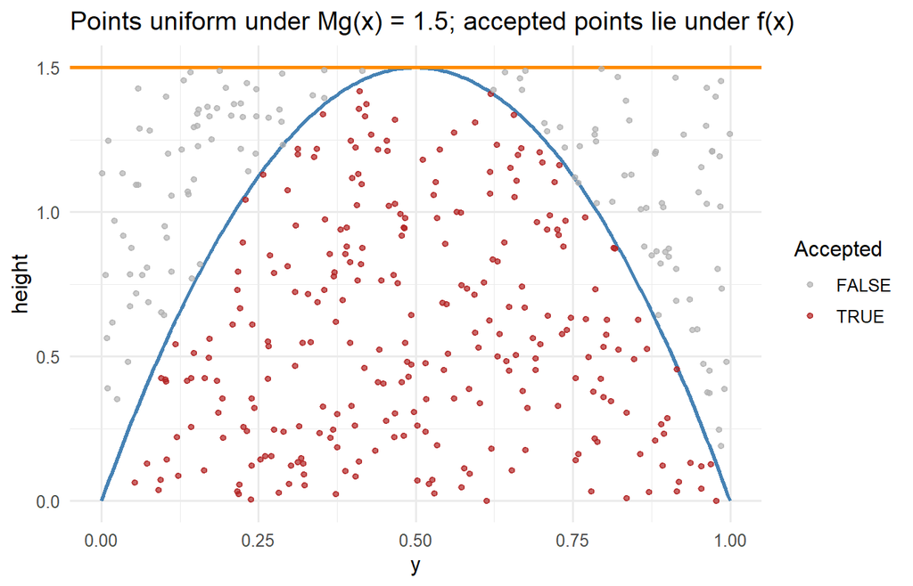

The picture also makes the efficiency of the method transparent: the fraction of candidate points that are accepted is exactly the ratio of the area under $f$ (which is $1$, since $f$ is a density) to the area under $Mg$ (which is $M$, since $g$ is a density). An envelope that hugs the target closely, with $M$ close to its minimum possible value, wastes little effort on rejected points; a loose envelope with large $M$ wastes most of its draws.

# 5 Formal Definitions

## 5.1 The Acceptance-Rejection Setup

**Definition.** Let $f$ be a target probability density on a support $\mathcal{X}$, and let $g$ be a **proposal density** (also called an **envelope density** or **instrumental density**) on the same support, from which random variates can be readily generated. Suppose there exists a finite constant $M \ge 1$, called the **bounding constant**, such that

$$f(x) \le M\,g(x) \qquad \text{for every } x \in \mathcal{X}.
\tag{4.1}$$

The **acceptance-rejection method** generates a candidate $Y \sim g$ together with an independent $U \sim \text{Uniform}(0,1)$, and accepts $X = Y$ if

$$U \le \frac{f(Y)}{M\,g(Y)},
\tag{4.2}$$

repeating with a fresh $(Y,U)$ pair whenever the candidate is rejected.

where

- $f$ denotes the density from which a sample is ultimately desired,
- $g$ denotes the density actually used to generate candidates,
- $M$ denotes the constant bounding the ratio $f/g$ over the entire support, so that the right-hand side of (4.2) never exceeds $1$,
- $U$ denotes the auxiliary uniform variate used to decide acceptance.

## 5.2 Conditional Distribution of the Accepted Variate

The central claim of the method, proved formally as Theorem 4.1 below, is that the variate reported by the algorithm — the value of $Y$ on the trial that is finally accepted — has *exactly* the conditional distribution

$$X \;\overset{d}{=}\; \bigl(Y \mid U \le f(Y)/(Mg(Y))\bigr),
\tag{4.3}$$

and that this conditional distribution coincides exactly with the target density $f$, not merely approximately. This is the feature that elevates the method from a heuristic to an exact simulation technique: however loose or tight the envelope $Mg$ is chosen (subject to $(4.1)$ holding), the output is never biased; only the *speed* of generation depends on the tightness of the envelope.

# 6 Theorems

## 6.1 Theorem 4.1: Correctness of the Acceptance-Rejection Algorithm

**Statement.** Let $f$ and $g$ be densities on a common support $\mathcal{X}$, and let $M \ge 1$ satisfy $f(x) \le Mg(x)$ for all $x \in \mathcal{X}$. If $Y \sim g$ and $U \sim \text{Uniform}(0,1)$ independently, and $X$ denotes the value of $Y$ conditional on the event $\{U \le f(Y)/(Mg(Y))\}$, then $X$ has density exactly $f$. Moreover, the probability that any given trial is accepted equals $1/M$.

**Assumptions.** $g(x) > 0$ wherever $f(x) > 0$ (so that the ratio $f(x)/g(x)$ is well defined on the support of $f$), and $M$ is finite.

**Proof.** For a fixed candidate $Y=y$, the conditional acceptance probability is

$$P\bigl(U \le f(y)/(Mg(y)) \mid Y=y\bigr) = \frac{f(y)}{Mg(y)},$$

since $U$ is Uniform$(0,1)$ and the right-hand side of (4.2) lies in $[0,1]$ by the bounding condition (4.1). Averaging over the distribution of $Y$ gives the unconditional acceptance probability

$$P(\text{accept}) = \int_{\mathcal{X}} \frac{f(y)}{Mg(y)}\, g(y)\, dy
= \frac{1}{M}\int_{\mathcal{X}} f(y)\, dy = \frac{1}{M},
\tag{4.4}$$

using $\int f = 1$ since $f$ is a density. This proves the second claim. For the first claim, fix $x \in \mathcal{X}$ and compute the joint probability that $Y \le x$ *and* the candidate is accepted:

$$P(Y \le x,\ \text{accept})
= \int_{-\infty}^{x} \frac{f(y)}{Mg(y)}\, g(y)\, dy
= \frac{1}{M}\int_{-\infty}^{x} f(y)\, dy
= \frac{F(x)}{M},
\tag{4.5}$$

where $F$ is the cumulative distribution function of $f$. By the definition of conditional probability and using (4.4) and (4.5),

$$P(X \le x) = P(Y \le x \mid \text{accept})
= \frac{P(Y\le x,\ \text{accept})}{P(\text{accept})}
= \frac{F(x)/M}{1/M} = F(x).$$

Since $P(X \le x) = F(x)$ for every $x$, the accepted variate $X$ has cumulative distribution function $F$, and hence density $f$. $\blacksquare$

**Remarks.** An equivalent, purely geometric argument reaches the same conclusion without any integration. The pair $(Y, U\!\cdot\! Mg(Y))$ is uniformly distributed over the two-dimensional region lying under the curve $Mg$, because $Y$ has marginal density $g$ and, given $Y=y$, the second coordinate is uniform on $(0, Mg(y))$ by construction; a standard fact about the uniform distribution on a planar region under a curve is that its horizontal marginal is proportional to the height of the curve. Restricting attention to the sub-region lying under $f$ (the accepted points) therefore gives a distribution uniform under $f$, whose horizontal marginal is $f$ itself, exactly reproducing the figure in the Intuition section. Both arguments are standard; see Devroye (1986, Ch. II) and Robert & Casella (2004, Ch. 2).

**Examples.** Full worked numerical examples appear later in this unit for both a bounded target (Beta) and an unbounded target (half-Normal).

**Applications.** Because the proof of (4.5) only ever uses $f$ through the integral $\int f$, the same argument goes through unchanged if $f$ is replaced everywhere by an *unnormalized* density $\tilde f = c f$ for an unknown constant $c > 0$, provided $M$ is re-chosen to satisfy $\tilde f \le M g$. The accepted variate is still exactly distributed as $f$, without $c$ ever being computed. This property is the reason acceptance-rejection is so widely used in Bayesian computation, where a posterior density is typically available only up to its normalizing constant.

## 6.2 Theorem 4.2: Number of Trials Until Acceptance

**Statement.** Under the conditions of Theorem 4.1, the number of independent trials $N$ required until the first acceptance (inclusive of the accepted trial) follows a Geometric distribution with success probability $1/M$,

$$P(N = k) = \Bigl(1-\frac1M\Bigr)^{k-1}\frac1M, \qquad k=1,2,\dots,$$

and hence $E(N) = M$.

**Proof.** Successive trials are independent and identically distributed, each with acceptance probability $1/M$ by (4.4). The number of independent Bernoulli$(1/M)$ trials up to and including the first success is, by definition, Geometric$(1/M)$, with mean $1/(1/M) = M$. $\blacksquare$

# 7 Mathematical Derivations

## 7.1 The Optimal (Minimal) Bounding Constant

Since $E(N) = M$ by Theorem 4.2, computational efficiency is directly governed by how small $M$ can be made while still satisfying $f(x) \le Mg(x)$ for every $x$. Rearranging (4.1),

$$M \ge \sup_{x \,:\, g(x) > 0} \frac{f(x)}{g(x)},$$

so the smallest valid choice is

$$M^{*} = \sup_{x} \frac{f(x)}{g(x)},
\tag{4.6}$$

provided this supremum is finite. Using $M = M^{*}$ maximizes the acceptance probability $1/M$ for the given proposal $g$; a poorer choice of $g$, even paired with its own optimal $M^{*}$, can still give a much larger $M^{*}$ than a better-matched proposal would. Two practical consequences follow immediately. First, $g$ should have the same support as $f$ (or larger), since $f(x) \le Mg(x)$ is impossible to satisfy wherever $g(x) = 0$ but $f(x) > 0$. Second, $g$ should have tails at least as heavy as those of $f$; if $g$’s tail decays faster than $f$’s tail, the ratio $f(x)/g(x)$ diverges and no finite $M$ exists at all, so the method cannot be used in that pairing — a concrete instance is attempting to generate Cauchy variates using a Normal proposal, which fails because the Cauchy density decays only polynomially while the Normal density decays like $e^{-x^2/2}$.

## 7.2 Exponential Tilting

For distributions whose interesting behaviour lies deep in a tail — extreme value analysis, ruin probabilities in insurance mathematics, rare-event simulation in reliability engineering — the natural proposal $g$ equal to the parent distribution itself gives a disastrously small acceptance probability, because almost all mass of $g$ lies away from the tail of interest. **Exponential tilting** (also called exponential twisting, or the Esscher transform in actuarial science) constructs a family of proposal densities better matched to a target region by re-weighting a base density with an exponential factor.

**Definition.** Given a density $h$ with moment generating function $M_h(\theta) = E_h[e^{\theta X}] < \infty$ on some interval of $\theta$, the **exponentially tilted density** with tilting parameter $\theta$ is

$$h_\theta(x) = \frac{e^{\theta x}\, h(x)}{M_h(\theta)}.
\tag{4.7}$$

Increasing $\theta$ shifts probability mass of $h_\theta$ toward larger values of $x$, which makes $h_\theta$ an effective proposal for sampling from the right tail of a related target density; the tilting parameter $\theta$ is a free design choice, and its optimal value is the one minimizing the resulting bounding constant $M^{*}$ in (4.6).

**Worked construction: sampling the right tail of the standard Normal.** Let $Z$ be a target variable with the standard Normal density $\varphi(z) = (2\pi)^{-1/2} e^{-z^2/2}$, and suppose the goal is to simulate from $Z$ conditional on $Z > a$ for a large threshold $a > 0$, i.e. from the truncated density

$$f(x) = \frac{\varphi(x)}{Q(a)}, \qquad x > a,
\qquad Q(a) = P(Z>a) = 1-\Phi(a).$$

Sampling $Z$ unconditionally and discarding all draws with $Z \le a$ works in principle but has acceptance probability $Q(a)$, which becomes vanishingly small as $a$ grows — for $a=4$, roughly one draw in $30{,}000$ is retained. Exponential tilting of the shifted Exponential family provides a dramatically better proposal. Take as the base density the Exponential$(1)$ density shifted to start at $a$, and tilt with parameter $\theta = a$, giving the proposal

$$g(x) = a\,e^{-a(x-a)}, \qquad x > a,$$

i.e. $Y = a + E$ with $E \sim \text{Exponential}(\text{rate}=a)$. Substituting into the ratio $f(x)/g(x)$ and completing the square,

$$\begin{aligned}
\frac{f(x)}{g(x)}
&= \frac{1}{Q(a)\,a\sqrt{2\pi}}\, \exp\Bigl(-\tfrac{x^2}{2} +
ax\Bigr) \\
&= \frac{1}{Q(a)\,a\sqrt{2\pi}}\, \exp\Bigl(-\tfrac{(x-a)^2}{2} -
\tfrac{a^2}{2}\Bigr) ,
\end{aligned}
\tag{4.8}$$

using $-\tfrac{x^2}{2}+ax = -\tfrac{(x-a)^2}{2} - \tfrac{a^2}{2}$, which is verified by expanding $(x-a)^2 = x^2 - 2ax + a^2$. Since $x>a$, the factor $\exp(-(x-a)^2/2)$ is at most $1$, attained only in the limit $x \to a^{+}$, so the supremum of (4.8) is

$$M^{*} = \frac{e^{-a^2/2}}{Q(a)\,a\sqrt{2\pi}} =
\frac{\varphi(a)}{a\,Q(a)}.
\tag{4.9}$$

Dividing (4.8) by (4.9) shows that the acceptance ratio has the remarkably simple form

$$\frac{f(x)}{M^{*}g(x)} = e^{-(x-a)^2/2},
\tag{4.10}$$

which depends only on the *excess* $x-a$ of the candidate above the threshold, and involves no evaluation of $\Phi$ or $Q$ at run time. Because $-\log U \sim \text{Exponential}(1)$ whenever $U \sim \text{Uniform}(0,1)$, the acceptance rule $U \le e^{-(x-a)^2/2}$ is equivalent to $-\log U \ge (x-a)^2/2$, so drawing a second, independent Exponential$(1)$ variate $E_2$ and accepting whenever $E_2 \ge (Y-a)^2/2$ implements the algorithm with no uniform variate and no transcendental function evaluation beyond squaring — the classical “two exponentials” algorithm of Marsaglia (1964), reproduced as Algorithm 4.3 below.

By the Mills ratio approximation $Q(a) \sim \varphi(a)/a$ as $a \to \infty$, expression (4.9) shows $M^{*} \to 1$ as $a \to \infty$: the larger the threshold, the *more* efficient the tilted algorithm becomes, in sharp contrast to naive rejection from the untilted Normal, whose acceptance probability $Q(a) \to 0$. This inversion of the usual difficulty — the tail becomes easier, not harder, to sample — is the defining benefit of exponential tilting for rare-event simulation.

# 8 Algorithms

## 8.1 Algorithm 4.1: General Acceptance-Rejection Algorithm

**Purpose.** Generate a sample from a target density $f$ using only a proposal density $g$ and a valid bounding constant $M$, without requiring a closed-form quantile function for $f$.

**Input.** Target density (or unnormalized density) $f$; proposal density $g$, from which variates can be simulated; bounding constant $M$ satisfying $f(x) \le Mg(x)$ on the support; required sample size $n$.

**Output.** A vector $x_1, \dots, x_n$ of simulated observations from $f$.

**Step-by-step procedure.**

1. Set the accepted-count to $0$ and initialize an empty output vector.
2. While fewer than $n$ values have been accepted:
   1. draw a candidate $Y \sim g$;
   2. draw $U \sim \text{Uniform}(0,1)$, independent of $Y$;
   3. if $U \le f(Y)/(Mg(Y))$, append $Y$ to the output and increment the accepted-count; otherwise discard $Y$ and $U$ and repeat.
3. Return the vector of $n$ accepted values.

**Pseudo-code.**

```
Algorithm: Acceptance-Rejection
Input:  f, g, M, n
Output: vector x of length n

1. accepted <- 0
2. x <- empty vector
3. While accepted < n:
       y <- draw from g
       u <- draw from Uniform(0,1)
       If u <= f(y) / (M * g(y)):
           append y to x
           accepted <- accepted + 1
4. Return x
```

**Flowchart description.** Start; draw a candidate from the proposal; draw an independent uniform variate; compare the uniform variate to the acceptance ratio; if it does not exceed the ratio, record the candidate as an accepted observation, otherwise discard both draws; repeat until the required number of observations has been collected; end.

**Complexity.** Each iteration costs $O(1)$ (one draw from $g$, one uniform draw, one ratio evaluation), and by Theorem 4.2 the expected number of iterations per accepted value is $M$, so the expected total cost to produce $n$ observations is $O(Mn)$.

**Practical considerations.** All density evaluations should be performed on the log scale, comparing $\log U \le \log f(Y) - \log M - \log g(Y)$, whenever $f$ or $g$ can take very small values, to avoid floating-point underflow.

## 8.2 Algorithm 4.2: Acceptance-Rejection with a Uniform Envelope (Bounded Target)

**Purpose.** Generate a sample from a bounded density on a bounded interval using the simplest possible envelope: a Uniform distribution on the same interval, scaled by the maximum height of the target.

**Input.** Target density $f$ on $[0,1]$ with known maximum value $f_{\max}$; sample size $n$.

**Output.** A vector of $n$ simulated observations from $f$.

**Step-by-step procedure.**

1. Set $M = f_{\max}$ and $g(x) = 1$ on $[0,1]$.
2. Apply Algorithm 4.1 with this $g$ and $M$.

**Pseudo-code.**

```
Algorithm: Acceptance-Rejection, Uniform Envelope
Input:  f, f_max, n
Output: vector x of length n

1. M <- f_max
2. accepted <- 0
3. x <- empty vector
4. While accepted < n:
       y <- Uniform(0,1)
       u <- Uniform(0,1)
       If u <= f(y) / M:
           append y to x
           accepted <- accepted + 1
5. Return x
```

**Flowchart description.** Identical to Algorithm 4.1, specialized so that generating the candidate $Y$ is itself a single uniform draw and the envelope height is the constant $f_{\max}$.

**Complexity.** $O(M n)$ expected time, with $M = f_{\max}$ for the Uniform$(0,1)$ envelope; a worked value of $M$ for a specific target (the Beta$(2,2)$ density) is given in the Numerical Examples section.

**Practical considerations.** This envelope is only viable when the target is bounded and has bounded support; it becomes inefficient when $f$ is sharply peaked, since $f_{\max}$ (and hence $M$) grows large relative to the typical height of $f$ away from its mode.

## 8.3 Algorithm 4.3: Exponentially Tilted Envelope for Normal Tail Simulation

**Purpose.** Efficiently generate observations from the standard Normal distribution conditioned on exceeding a threshold $a$, using the tilted Exponential envelope derived in Section 7.2, via the “two exponentials” implementation that avoids evaluating $\varphi$, $\Phi$, or any exponential function beyond the two auxiliary draws.

**Input.** Threshold $a > 0$; sample size $n$.

**Output.** A vector of $n$ simulated observations from the standard Normal distribution truncated to $(a, \infty)$.

**Step-by-step procedure.**

1. While fewer than $n$ values have been accepted:
   1. draw $E_1 \sim \text{Exponential}(\text{rate}=a)$ and set candidate $Y = a + E_1$;
   2. draw $E_2 \sim \text{Exponential}(\text{rate}=1)$, independently;
   3. if $E_2 \ge E_1^2/2$, accept $Y$; otherwise discard both draws.
2. Return the vector of accepted values.

**Pseudo-code.**

```
Algorithm: Tilted-Exponential Normal Tail Sampler
Input:  a, n
Output: vector x of length n

1. accepted <- 0
2. x <- empty vector
3. While accepted < n:
       e1 <- Exponential(rate = a)
       e2 <- Exponential(rate = 1)
       If e2 >= e1^2 / 2:
           append (a + e1) to x
           accepted <- accepted + 1
4. Return x
```

**Flowchart description.** Start; draw two independent exponential variates; compare the second against half the square of the first; if the check passes, report the threshold plus the first exponential as an accepted tail observation; otherwise discard both and repeat; end.

**Complexity.** $O(M^{*} n)$ expected time, with $M^{*}$ given explicitly by (4.9); crucially, $M^{*} \to 1$ as $a \to \infty$, so unlike Algorithms 4.1-4.2, this method becomes *more* efficient as the target region becomes more extreme.

**Practical considerations.** For $a \le 0$, the shifted-Exponential envelope is not the natural choice (a direct Normal draw, discarding values below the threshold, is simpler and already efficient when the threshold is not deep in the tail); the tilted method is intended specifically for moderate-to-large positive thresholds.

# 9 R Programming

```r
set.seed(123)

#' Generate variates by the general acceptance-rejection algorithm
#'
#' Purpose: implements Algorithm 4.1, drawing candidates from a
#' user-supplied proposal generator and accepting them according to
#' the ratio of the target density to the scaled proposal density.
#'
#' Arguments:
#'   sample_size        number of accepted observations required
#'   target_density     function f(x) evaluating the target density
#'   proposal_density    function g(x) evaluating the proposal density
#'   proposal_sampler    function() returning one draw from g
#'   bounding_constant   the constant M with f(x) <= M * g(x)
#'
#' Returns:
#'   a list with the accepted sample (`sample`) and the empirical
#'   acceptance rate (`acceptance_rate`)
#'
#' Example:
#'   accept_reject(
#'     sample_size = 1000,
#'     target_density = function(x) 6 * x * (1 - x),
#'     proposal_density = function(x) rep(1, length(x)),
#'     proposal_sampler = function() runif(1),
#'     bounding_constant = 1.5
#'   )
accept_reject <- function(sample_size, target_density, proposal_density,
                           proposal_sampler, bounding_constant) {
  accepted_values <- numeric(sample_size)
  accepted_count <- 0
  total_trials <- 0

  while (accepted_count < sample_size) {
    candidate <- proposal_sampler()
    uniform_draw <- runif(1)
    total_trials <- total_trials + 1

    acceptance_ratio <- target_density(candidate) /
      (bounding_constant * proposal_density(candidate))

    if (uniform_draw <= acceptance_ratio) {
      accepted_count <- accepted_count + 1
      accepted_values[accepted_count] <- candidate
    }
  }

  list(
    sample = accepted_values,
    acceptance_rate = sample_size / total_trials
  )
}

#' Generate right-tail standard Normal variates via exponential tilting
#'
#' Purpose: implements Algorithm 4.3, the two-exponentials method for
#' simulating Z | Z > a efficiently for large thresholds a.
#'
#' Arguments:
#'   sample_size    number of accepted observations required
#'   threshold      the truncation threshold a (a > 0)
#'
#' Returns:
#'   a list with the accepted sample (`sample`) and the empirical
#'   acceptance rate (`acceptance_rate`)
#'
#' Example:
#'   tilted_normal_tail(sample_size = 1000, threshold = 2)
tilted_normal_tail <- function(sample_size, threshold) {
  accepted_values <- numeric(sample_size)
  accepted_count <- 0
  total_trials <- 0

  while (accepted_count < sample_size) {
    first_exponential <- rexp(1, rate = threshold)
    second_exponential <- rexp(1, rate = 1)
    total_trials <- total_trials + 1

    if (second_exponential >= first_exponential^2 / 2) {
      accepted_count <- accepted_count + 1
      accepted_values[accepted_count] <- threshold + first_exponential
    }
  }

  list(
    sample = accepted_values,
    acceptance_rate = sample_size / total_trials
  )
}
```

# 10 Simulation Studies

## 10.1 Half-Normal Density via an Exponential(1) Envelope

The half-Normal density $f(x) = \sqrt{2/\pi}\, e^{-x^2/2}$, $x>0$, is generated using the Exponential$(1)$ proposal $g(x) = e^{-x}$, with bounding constant $M^{*} = \sqrt{2e/\pi}$ derived in the Numerical Examples section below.

```r
set.seed(123)

m_half_normal <- sqrt(2 * exp(1) / pi)

half_normal_result <- accept_reject(
  sample_size = 20000,
  target_density = function(x) sqrt(2 / pi) * exp(-x^2 / 2),
  proposal_density = function(x) exp(-x),
  proposal_sampler = function() rexp(1, rate = 1),
  bounding_constant = m_half_normal
)

tibble(
  Quantity = c("Theoretical M", "Theoretical acceptance rate (1/M)", "Empirical acceptance rate"),
  Value = c(m_half_normal, 1 / m_half_normal, half_normal_result$acceptance_rate)
) %>%
  kable(digits = 4, caption = "Half-Normal acceptance-rejection: theory vs simulation")
```

Half-Normal acceptance-rejection: theory vs simulation

| Quantity | Value |
| --- | --- |
| Theoretical M | 1.3155 |
| Theoretical acceptance rate (1/M) | 0.7602 |
| Empirical acceptance rate | 0.7607 |

The empirical acceptance rate closely tracks the theoretical value $1/M^{*} \approx 0.760$, confirming Theorem 4.2 directly.

## 10.2 Beta(2,2) Density via a Uniform Envelope

```r
set.seed(123)

beta_result <- accept_reject(
  sample_size = 20000,
  target_density = function(x) 6 * x * (1 - x),
  proposal_density = function(x) rep(1, length(x)),
  proposal_sampler = function() runif(1),
  bounding_constant = 1.5
)

tibble(
  Quantity = c("Theoretical M", "Theoretical acceptance rate (1/M)", "Empirical acceptance rate"),
  Value = c(1.5, 1 / 1.5, beta_result$acceptance_rate)
) %>%
  kable(digits = 4, caption = "Beta(2,2) acceptance-rejection: theory vs simulation")
```

Beta(2,2) acceptance-rejection: theory vs simulation

| Quantity | Value |
| --- | --- |
| Theoretical M | 1.5000 |
| Theoretical acceptance rate (1/M) | 0.6667 |
| Empirical acceptance rate | 0.6658 |

## 10.3 Exponential Tilting vs. Naive Rejection for the Normal Tail

This simulation contrasts the tilted “two exponentials” algorithm against the naive strategy of drawing standard Normal variates and discarding those at or below the threshold, for a moderately deep threshold $a=3$.

```r
set.seed(123)

threshold_value <- 3
q_theoretical <- 1 - pnorm(threshold_value)

# Naive method: draw standard Normal variates, keep only those above a
naive_trials <- 200000
naive_draws <- rnorm(naive_trials)
naive_acceptance_rate <- mean(naive_draws > threshold_value)

# Tilted method
tilted_result <- tilted_normal_tail(sample_size = 5000, threshold = threshold_value)

m_tilted_theoretical <- dnorm(threshold_value) / (threshold_value * q_theoretical)

comparison_tbl <- tibble(
  Method = c("Naive (discard Z <= a)", "Exponentially tilted (two exponentials)"),
  Theoretical_Acceptance_Rate = c(q_theoretical, 1 / m_tilted_theoretical),
  Empirical_Acceptance_Rate = c(naive_acceptance_rate, tilted_result$acceptance_rate)
)

kable(comparison_tbl, digits = 5,
      caption = "Naive rejection vs. exponentially tilted rejection for Z | Z > 3")
```

Naive rejection vs. exponentially tilted rejection for Z | Z > 3

| Method | Theoretical_Acceptance_Rate | Empirical_Acceptance_Rate |
| --- | --- | --- |
| Naive (discard Z <= a) | 0.00135 | 0.00140 |
| Exponentially tilted (two exponentials) | 0.91377 | 0.91592 |

The tilted method accepts the overwhelming majority of its candidates, while the naive method accepts roughly one candidate in every $1/Q(3) \approx 741$; the tilted algorithm therefore requires several orders of magnitude fewer total random draws to produce the same number of tail observations, exactly as predicted by the asymptotic argument following (4.9).

# 11 Graphs

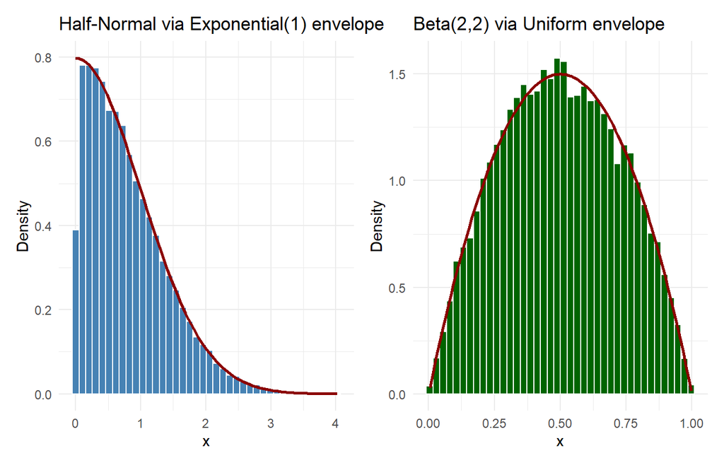

Simulated samples (histograms) against theoretical target densities (curves) for the half-Normal (left) and Beta(2,2) (right) acceptance-rejection examples.

```r
set.seed(123)

p_half_normal <- ggplot(tibble(x = half_normal_result$sample), aes(x = x)) +
  geom_histogram(aes(y = after_stat(density)), bins = 40, fill = "steelblue", colour = "white") +
  stat_function(fun = function(x) sqrt(2 / pi) * exp(-x^2 / 2), colour = "darkred", linewidth = 1) +
  labs(title = "Half-Normal via Exponential(1) envelope", x = "x", y = "Density") +
  theme_minimal(base_size = 11)

p_beta <- ggplot(tibble(x = beta_result$sample), aes(x = x)) +
  geom_histogram(aes(y = after_stat(density)), bins = 40, fill = "darkgreen", colour = "white") +
  stat_function(fun = function(x) 6 * x * (1 - x), colour = "darkred", linewidth = 1) +
  labs(title = "Beta(2,2) via Uniform envelope", x = "x", y = "Density") +
  theme_minimal(base_size = 11)

p_half_normal + p_beta
```

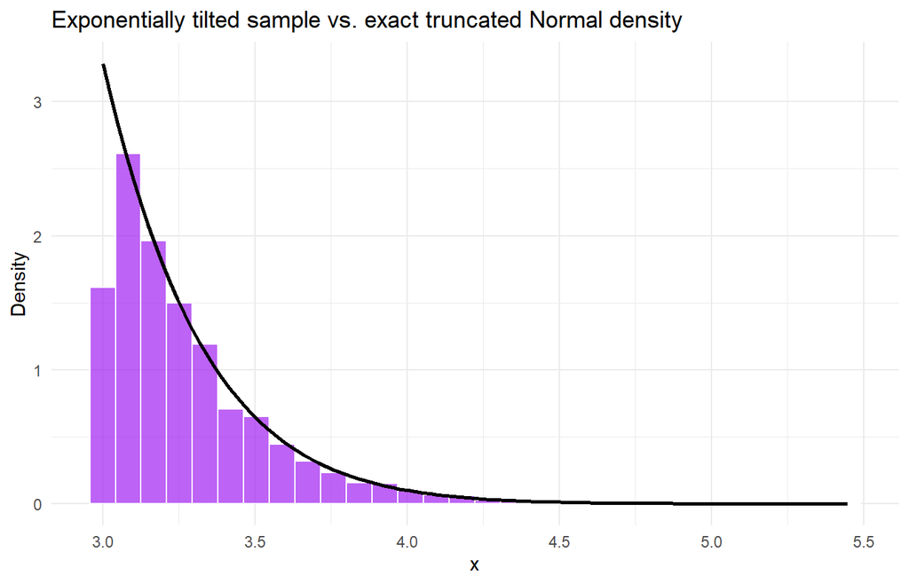

Simulated tilted-envelope sample against the exact truncated Normal density for Z | Z > 3.

```r
set.seed(123)

truncated_normal_density <- function(x, threshold) {
  dnorm(x) / (1 - pnorm(threshold))
}

ggplot(tibble(x = tilted_result$sample), aes(x = x)) +
  geom_histogram(aes(y = after_stat(density)), bins = 30, fill = "purple", colour = "white", alpha = 0.7) +
  stat_function(
    fun = truncated_normal_density, args = list(threshold = threshold_value),
    colour = "black", linewidth = 1
  ) +
  labs(
    title = "Exponentially tilted sample vs. exact truncated Normal density",
    x = "x", y = "Density"
  ) +
  theme_minimal(base_size = 11)
```

# 12 Numerical Examples

**Example 1: Bounding constant and one iteration for the half-Normal density.**

*Problem.* Using the target $f(x) = \sqrt{2/\pi}\,e^{-x^2/2}$, $x>0$, and proposal $g(x)=e^{-x}$, derive $M^{*}$ and determine whether the candidate $y=0.8$ with $u=0.30$ is accepted.

*Solution.* The ratio is $f(x)/g(x) = \sqrt{2/\pi}\,\exp(-x^2/2+x)$. Writing the exponent as $-\tfrac12(x-1)^2 + \tfrac12$ (completing the square as in (4.8)-(4.9) with $a=1$), the maximum over $x>0$ occurs at $x=1$, giving

$$M^{*} = \sqrt{2/\pi}\,e^{1/2} = \sqrt{2e/\pi} \approx 1.3155.$$

For the candidate $y=0.8$: $f(0.8) = \sqrt{2/\pi}\,e^{-0.32} = 0.7979\times 0.7261 = 0.5794$, and $M^{*}g(0.8) = 1.3155\times e^{-0.8} = 1.3155\times 0.4493 = 0.5911$. The acceptance ratio is $0.5794/0.5911 = 0.9802$. Since $u=0.30 \le 0.9802$, the candidate is **accepted**, and $x=0.8$ is reported.

*Interpretation.* Because $0.8$ is close to the mode $1$ of the ratio $f/g$, the acceptance ratio is close to its maximum value of $1$; a candidate far from this mode would have a much smaller acceptance ratio and would be rejected more often, which is exactly the pattern verified in bulk by the simulation study above.

**Example 2: Manual acceptance-rejection trial for Beta(2,2).**

*Problem.* Using $f(x) = 6x(1-x)$ on $(0,1)$ and the Uniform$(0,1)$ envelope with $M=1.5$, determine the outcome for the candidate $y=0.9$ with $u=0.5$, and separately for $y=0.9$ with $u=0.2$.

*Solution.* $f(0.9) = 6(0.9)(0.1) = 0.54$, and $Mg(0.9) = 1.5(1) = 1.5$, so the acceptance ratio is $0.54/1.5 = 0.36$. With $u=0.5$, since $0.5 > 0.36$, the candidate is **rejected**. With $u=0.2$, since $0.2 \le 0.36$, the candidate is **accepted**, and $x=0.9$ is reported.

*Interpretation.* The value $y=0.9$ lies far from the mode of the Beta$(2,2)$ density (which is at $x=0.5$), so its acceptance ratio of $0.36$ is well below $1$; roughly $64\%$ of candidates equal to $0.9$ would be rejected, consistent with the overall acceptance rate of $1/1.5 \approx 0.667$ averaged across all candidate locations.

**Example 3: Exponential tilting for the Normal tail at $a=2$.**

*Problem.* Compute the optimal bounding constant $M^{*}$ and the acceptance probability for simulating $Z \mid Z>2$ using the exponentially tilted envelope with $\theta=a=2$.

*Solution.* From (4.9), $M^{*} = \varphi(2)/(2\,Q(2))$. Using $\varphi(2) = (2\pi)^{-1/2}e^{-2} = 0.05399$ and $Q(2) = 1-\Phi(2) = 0.02275$,

$$M^{*} = \frac{0.05399}{2 \times 0.02275} = \frac{0.05399}{0.04550}
= 1.1866,$$

so the acceptance probability is $1/M^{*} \approx 0.8427$. By contrast, the naive method of drawing $Z\sim N(0,1)$ and discarding $Z \le 2$ has acceptance probability $Q(2) = 0.02275$ — the tilted method is roughly $37$ times more efficient at this threshold, and this efficiency ratio grows without bound as the threshold increases further.

*Interpretation.* The R simulation for threshold $a=3$ above shows the same phenomenon even more starkly, since the naive acceptance rate $Q(3) \approx 0.00135$ falls rapidly with $a$ while the tilted acceptance rate stays comfortably above $0.9$.

# 13 Applications

- **Statistics.** Exact simulation from non-standard likelihoods and from densities specified only up to a normalizing constant, a routine situation in maximum likelihood and Bayesian computation.
- **Machine Learning.** Sampling from complex latent-variable models and from priors or posteriors lacking a closed-form quantile function; acceptance-rejection also underlies certain reparameterization strategies for gradient-based training with non-standard noise distributions.
- **Data Science.** Generating synthetic data that matches an empirically estimated density for stress-testing pipelines, when the estimated density has no simple quantile function.
- **Finance.** Simulating extreme portfolio losses and tail risk measures (Value-at-Risk, Expected Shortfall) efficiently using exponential tilting rather than brute-force Monte Carlo.
- **Reliability Engineering.** Simulating rare early-failure or extreme-stress events for structural or component reliability analysis, where naive simulation would require an infeasible number of trials.
- **Monte Carlo Methods.** Acceptance-rejection is one of the two foundational exact-sampling techniques (alongside inverse transformation) taught in every Monte Carlo methods course, and importance sampling — a closely related variance-reduction technique — borrows the same tilting idea used in Section 7.2.
- **Bayesian Statistics.** Exact posterior sampling when the posterior kernel is bounded by a tractable envelope, and as the textbook benchmark against which the bias-variance trade-offs of Markov chain Monte Carlo approximations are explained.
- **Operations Research.** Simulating rare congestion or failure events in queueing and network reliability models.
- **Engineering.** Monte Carlo reliability analysis of systems subjected to random loads whose extreme-value behaviour, rather than typical behaviour, determines the design margin.